# Benchmarking: demultiplexing with genotyping vs HTO

HTO QC at the adopted threshold.

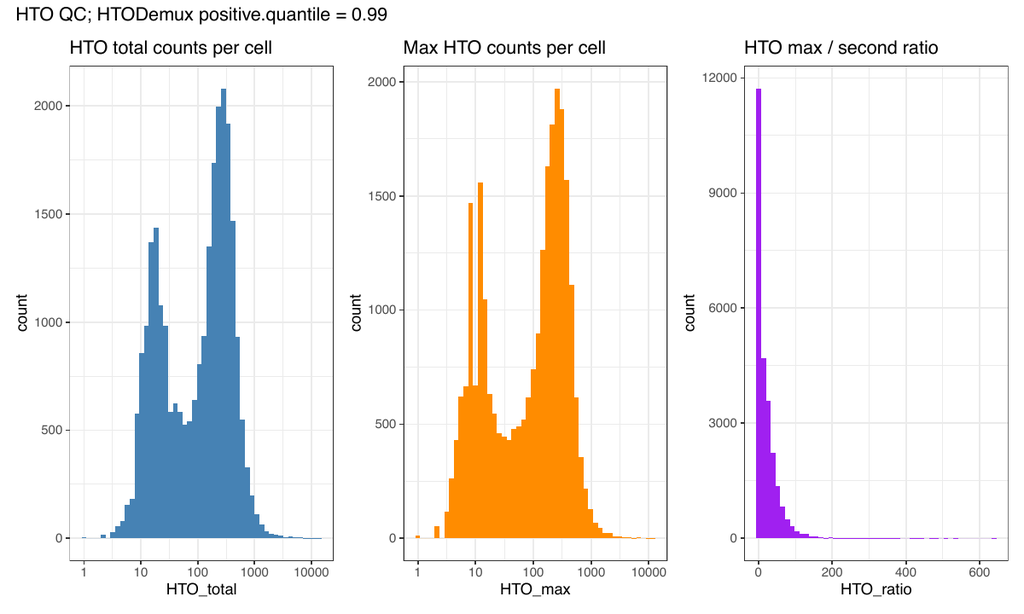

**`06_HTO_ridge_positive_quantile_0.99.pdf`**

Ridge plots per hashtag.

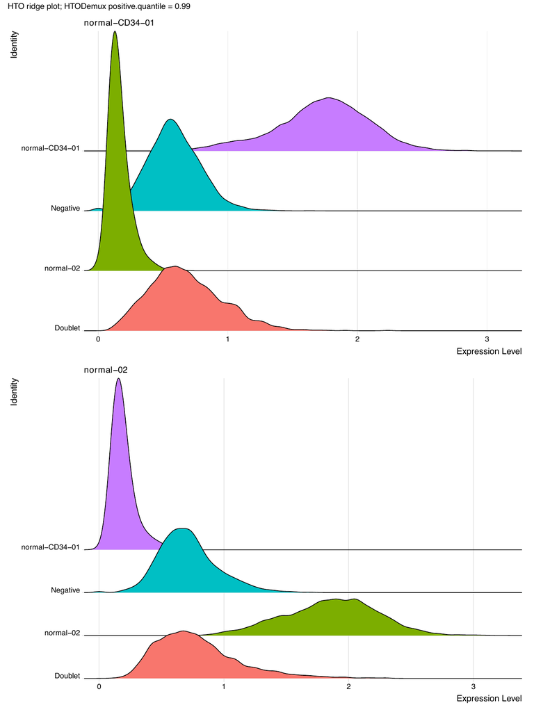

**`06b_HTO_ratio_thresholds_positive_quantile_0.99.pdf`**

HTO ratio thresholds.

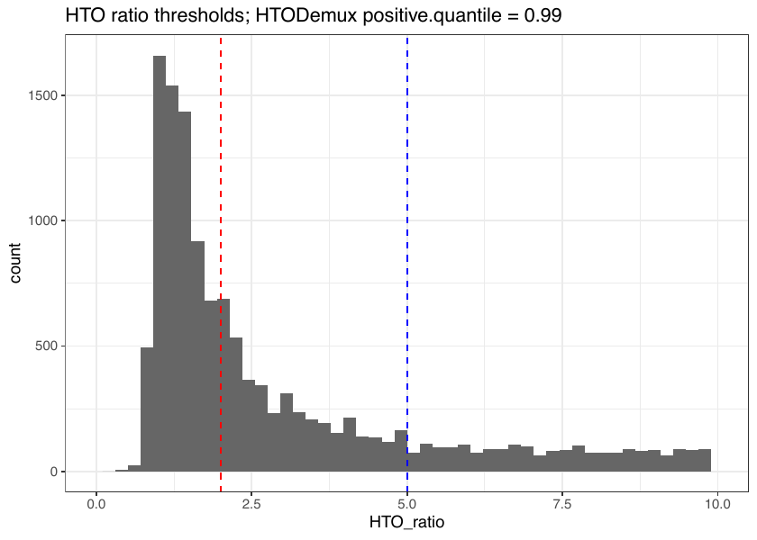

**`07_UMAP_HTO_cellSNP_positive_quantile_0.99.pdf`**

Both sets of calls on the UMAP.

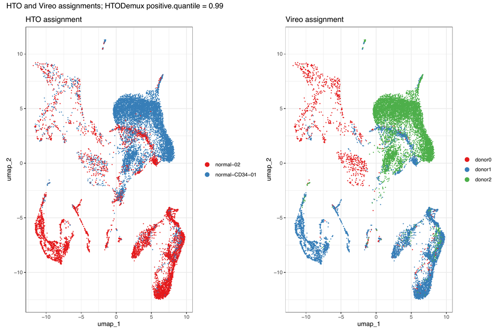

# 5. The unhashed donor

Not every donor in a pool carries a hashtag. Step 06 checks that case: it runs the production script `nextflow/bin/process_cellsnp_hto.R` with exactly the arguments the pipeline module would pass for LK3-GEX, against that run’s already-completed cellSNP/vireo and HTO output. Running the real script rather than a reimplementation is the point - it exercises the code that ships.

The trial output lives in `scripts/TRIAL_output_unhashed_donor_demux/`, deliberately outside `nextflow/`, following the convention that trial and diagnostic scripts never sit inside the pipeline directory.

# 6. What was run, in order

[output not shown]

The biotin-specific part of step 05 was later split into `scripts/6b1.biotin_ADT_comparison.R`, which belongs to the biotin report rather than here.

# 7. Data locations

Demux comparison outputs by run and source

| What | Location |
| --- | --- |
| Genotype demux | `results/genotype_demux/<run>/<sample>/cellsnp/` and `.../vireo/` |
| Comparison, standalone | `results/demux_comparison/<run>/<sample>/` |
| Comparison, pipeline | `results_nf/<run>/06_demux_comparison/` |
| HTO counts | `results/cite_seq_count/<run>/hto_counts_*/` |
| Unhashed-donor trial | `scripts/TRIAL_output_unhashed_donor_demux/` |

| run | source | files | first | last |
| --- | --- | --- | --- | --- |
| 260423 | standalone | 32 | 2026-05-04 | 2026-05-05 |
| 260522 | pipeline | 18 | 2026-07-28 | 2026-07-28 |
| 260528 | standalone | 24 | 2026-06-02 | 2026-06-03 |
| 260528 | pipeline | 18 | 2026-07-27 | 2026-07-27 |
| 260717 | pipeline | 18 | 2026-07-21 | 2026-07-21 |

# 8. Tools

| Tool | Version | Source |
| --- | --- | --- |
| cellsnp-lite | 1.2.3 (htslib 1.23.1) | `cellsnp_env` |
| vireo (vireoSNP) | to confirm | `cellsnp_env` |
| CITE-seq-Count | to confirm | `01.hto_count.sbatch` |
| Seurat `HTODemux` | see session below | `positive.quantile = 0.99` adopted |

# 9. Caveats

1. **The sweep exists only for the pilot run.** From LK2 onwards only the 0.99 outputs were generated, so the comparison across thresholds cannot be redone from saved files for the later runs without re-running step 03.
2. **`results/demux_comparison/` has no entry for LK1-resequenced or LK3.** Those runs were demultiplexed through the pipeline, so their comparison lives under `results_nf/<run>/`.
3. Vireo’s donor labels are anonymous; any statement tying a genotype cluster to a sample name depends on the HTO mapping in `vireo_to_hto_sample_name_map_positive_quantile_0.99.csv`.